```python
import requests
from PIL import Image
from io import BytesIO
```

```python
# 地理编码
key_huang = '679ab0b5933e8e27c9a7ccd7a36a554c'
def geo(address:str)->dict:
    """获取地理编码"""
    url = "https://restapi.amap.com/v3/geocode/geo?parameters"
    params = {
        "key" : key_huang,
        "address" : address,
        "output" :"json"
    }
    response = requests.get(url,params=params)
    data = response.json()
    return data

# 步行路径规划
def walking(origin,destination):
    """步行路径规划"""
    url = "https://restapi.amap.com/v3/direction/walking?parameters"
    params = {
        "key" : key_huang,
        "origin" : origin,
        "destination" :destination
    }
    response = requests.get(url,params=params)
    data = response.json()
    return data

# 行政区域查询
def district(keywords):
    """行政区域查询"""
    url = "https://restapi.amap.com/v3/config/district?parameters"
    params = {
        "key" : key_huang,
        "keywords" : keywords,
        "output" :"json"
    }
    response = requests.get(url,params=params)
    data = response.json()
    return data

# 交通态势
def rectangle(rectangle):
    """交通态势"""
    url = "https://restapi.amap.com/v3/traffic/status/rectangle?parameters"
    params = {
        "key" : key_huang,
        "rectangle": rectangle,
    }
    response = requests.get(url,params=params)
    data = response.json()
    return data
```

- 地理编码没有涉及ML、AI的功能
- 步行路径规划涉及了推荐算法功能，因为路径规划需要设计很多个不同的路线，从而利用推荐算法计算出最方便的道路才能完成规划。
- 行政区域查询没有涉及ML、AI的功能
- 交通态势没有涉及ML、AI的功能

```python
# 113.679287,23.632575 ,113.668051,23.600869
# geo("广东省广州市从化区中山大学南方学院")
geo("广东省广州市从化区龙岗")
```

```
{'status': '1',
 'info': 'OK',
 'infocode': '10000',
 'count': '1',
 'geocodes': [{'formatted_address': '广东省广州市从化区龙岗',
   'country': '中国',
   'province': '广东省',
   'citycode': '020',
   'city': '广州市',
   'district': '从化区',
   'township': [],
   'neighborhood': {'name': [], 'type': []},
   'building': {'name': [], 'type': []},
   'adcode': '440117',
   'street': [],
   'number': [],
   'location': '113.668051,23.600869',
   'level': '热点商圈'}]}
```

```python
walking("113.679287,23.632575" ,"113.668051,23.600869")
```

```
{'status': '1',
 'info': 'ok',
 'infocode': '10000',
 'count': '1',
 'route': {'origin': '113.679287,23.632575',
  'destination': '113.668051,23.600869',
  'paths': [{'distance': '4667',
    'duration': '3734',
    'steps': [{'instruction': '向南步行161米右转',
      'orientation': '南',
      'road': [],
      'distance': '161',
      'duration': '129',
      'polyline': '113.679592,23.632088;113.679609,23.631003;113.679609,23.631003;113.679609,23.630877;113.67964,23.630638',
      'action': '右转',
      'assistant_action': [],
      'walk_type': '0'},
     {'instruction': '向西步行99米左转',
      'orientation': '西',
      'road': [],
      'distance': '99',
      'duration': '79',
      'polyline': '113.67964,23.630634;113.679362,23.630521;113.679201,23.630473;113.679201,23.630473;113.678711,23.630365',
      'action': '左转',
      'assistant_action': [],
      'walk_type': '0'},
     {'instruction': '向南步行237米左转',
      'orientation': '南',
      'road': [],
      'distance': '237',
      'duration': '190',
      'polyline': '113.678711,23.63036;113.678711,23.62934;113.678711,23.62934;113.678707,23.629132;113.678668,23.629058;113.678576,23.628989;113.678424,23.628902;113.678368,23.628841;113.678333,23.628776;113.678303,23.62865;113.678277,23.628372',
      'action': '左转',
      'assistant_action': [],
      'walk_type': '0'},
     {'instruction': '向南步行498米向右前方行走',
      'orientation': '南',
      'road': [],
      'distance': '498',
      'duration': '398',
```

[output cut: 52 more lines]

```
      'distance': '673',
      'duration': '538',
      'polyline': '113.675009,23.604735;113.674236,23.604683;113.673893,23.604618;113.673464,23.604492;113.673464,23.604492;113.672457,23.60421;113.672457,23.60421;113.67168,23.604006;113.671541,23.603958;113.671411,23.603854;113.671068,23.603472;113.670807,23.603264;113.670807,23.603264;113.670525,…
      'action': '向右前方行走',
      'assistant_action': [],
      'walk_type': '0'},
     {'instruction': '沿桃园东路向西南步行215米到达目的地',
      'orientation': '西南',
      'road': '桃园东路',
      'distance': '215',
      'duration': '172',
      'polyline': '113.669714,23.601897;113.66964,23.601771;113.66964,23.601771;113.669488,23.601558;113.669488,23.601558;113.668789,23.600859;113.668663,23.600768;113.668663,23.600768;113.668442,23.600647;113.668234,23.600547',
      'action': [],
      'assistant_action': '到达目的地',
      'walk_type': '0'}]}]}}
```

```python
help(geo)
```

```
Help on function geo in module __main__:

geo(address: str) -> dict
    获取地理编码
```

```python
district("湖北")
```

```
{'status': '1',
 'info': 'OK',
 'infocode': '10000',
 'count': '1',
 'suggestion': {'keywords': [], 'cities': []},
 'districts': [{'citycode': [],
   'adcode': '420000',
   'name': '湖北省',
   'center': '114.298572,30.584355',
   'level': 'province',
   'districts': [{'citycode': '0710',
     'adcode': '420600',
     'name': '襄阳市',
     'center': '112.144146,32.042426',
     'level': 'city',
     'districts': []},
    {'citycode': '0719',
     'adcode': '420300',
     'name': '十堰市',
     'center': '110.787916,32.646907',
     'level': 'city',
     'districts': []},
    {'citycode': '027',
     'adcode': '420100',
     'name': '武汉市',
     'center': '114.298572,30.584355',
     'level': 'city',
     'districts': []},
    {'citycode': '0717',
     'adcode': '420500',
     'name': '宜昌市',
     'center': '111.290843,30.702636',
     'level': 'city',
     'districts': []},
    {'citycode': '0713',
     'adcode': '421100',
     'name': '黄冈市',
     'center': '114.879365,30.447711',
     'level': 'city',
     'districts': []},
```

[output cut: 57 more lines]

```
     'center': '113.453974,30.364953',
     'level': 'city',
     'districts': []},
    {'citycode': '0711',
     'adcode': '420700',
     'name': '鄂州市',
     'center': '114.890593,30.396536',
     'level': 'city',
     'districts': []},
    {'citycode': '0714',
     'adcode': '420200',
     'name': '黄石市',
     'center': '115.077048,30.220074',
     'level': 'city',
     'districts': []}]}]}
```

```python
rectangle("116.351147,39.966309;116.357134,39.968727")
```

```
{'status': '1',
 'info': 'OK',
 'infocode': '10000',
 'trafficinfo': {'description': '北三环路：双向畅通。',
  'evaluation': {'expedite': '100.00%',
   'congested': '0.00%',
   'blocked': '0.00%',
   'unknown': '0.00%',
   'status': '1',
   'description': '整体畅通'}}}
```

```python
# 搜索POI
key_huang = '679ab0b5933e8e27c9a7ccd7a36a554c'
def place(keywords):
    """搜索POI"""
    url = "https://restapi.amap.com/v3/place/text?parameters"
    params = {
        "key" : key_huang,
        "keywords" : keywords,
        "output" :"json"
    }
    response = requests.get(url,params=params)
    data = response.json()
    return data
```

```python
place("北京")
```

```
{'status': '1',
 'count': '888',
 'info': 'OK',
 'infocode': '10000',
 'suggestion': {'keywords': [], 'cities': []},
 'pois': [{'id': 'B000A83M61',
   'parent': [],
   'childtype': [],
   'name': '北京西站',
   'type': '交通设施服务;火车站;火车站',
   'typecode': '150200',
   'biz_type': [],
   'address': '莲花池东路118号',
   'location': '116.322056,39.89491',
   'tel': '010-51824233',
   'distance': [],
   'biz_ext': {'rating': '4.0', 'cost': []},
   'pname': '北京市',
   'cityname': '北京市',
   'adname': '丰台区',
   'importance': [],
   'shopid': [],
   'shopinfo': '2',
   'poiweight': [],
   'photos': [{'url': 'http://store.is.autonavi.com/showpic/778d4f452762efe0e80ccf924cb6340c',
     'provider': [],
     'title': []},
    {'url': 'http://store.is.autonavi.com/showpic/081c9845670a39eaa3bc1ce560e34b5f',
     'provider': [],
     'title': []},
    {'url': 'http://store.is.autonavi.com/showpic/ca50f93a8aa020e941f5ed0d4d9548cf',
     'provider': [],
     'title': []}]},
  {'id': 'B000A83C36',
   'parent': [],
   'childtype': [],
   'name': '北京站',
   'type': '交通设施服务;火车站;火车站',
   'typecode': '150200',
   'biz_type': [],
```

[output cut: 499 more lines]

```
   'cityname': '北京市',
   'adname': '东城区',
   'importance': [],
   'shopid': [],
   'shopinfo': '2',
   'poiweight': [],
   'photos': [{'url': 'http://store.is.autonavi.com/showpic/9ca0173d726b6d6f9f5efa6d6e50a642',
     'provider': [],
     'title': '外景图'},
    {'url': 'http://store.is.autonavi.com/showpic/707c56f64d2da3f51a15d095f1a42985',
     'provider': [],
     'title': []},
    {'url': 'http://store.is.autonavi.com/showpic/235f2eb64cc72651b660b8ed21fda692',
     'provider': [],
     'title': []}]}]}
```

- 搜索POI使用了机器学习功能，因为所有结果要更加精准，必须利用机器学习的功能，改进用户的反馈结果，使得搜索结果更加精确。

```python
# IP定位
key_huang = '679ab0b5933e8e27c9a7ccd7a36a554c'
def ip(key):
    """IP定位"""
    url = "https://restapi.amap.com/v3/ip?parameters"
    params = {
        "key" : key_huang,
    }
    response = requests.get(url,params=params)
    data = response.json()
    return data
```

```python
ip("114.247.50.2")
```

```
{'status': '1',
 'info': 'OK',
 'infocode': '10000',
 'province': '广东省',
 'city': '广州市',
 'adcode': '440100',
 'rectangle': '113.1017375,22.93212254;113.6770499,23.3809537'}
```

- IP定位同样使用了机器学习的功能，需要机器自己学习才能反馈更加精确的结果。

```python
# 批量请求接口
{
    "ops": [
        {
            "url": "https://restapi.amap.com/v3/place/around?offset=10&page=1&key=679ab0b5933e8e27c9a7ccd7a36a554c&location=116.50394379585519,39.278209477408794&output=json&radius=100000&types=080000"
        }
    ]
}
```

```
{'ops': [{'url': 'https://restapi.amap.com/v3/place/around?offset=10&page=1&key=679ab0b5933e8e27c9a7ccd7a36a554c&location=116.50394379585519,39.278209477408794&output=json&radius=100000&types=080000'}]}
```

- 批量请求接口没有涉及ML、AI的功能

```python
# 静态地图
def map_(location):
    """静态地图"""
    url = 'https://restapi.amap.com/v3/staticmap?parameters'
    params = {
        'key':key_huang,
        'location':location,
        'zoom':"16",
        "size":"1000*1000",
        "scale":"2",
        "traffic":"1",
    }
    response = requests.get(url,params=params)
    mapp = Image.open(BytesIO(response.content))
    return mapp
```

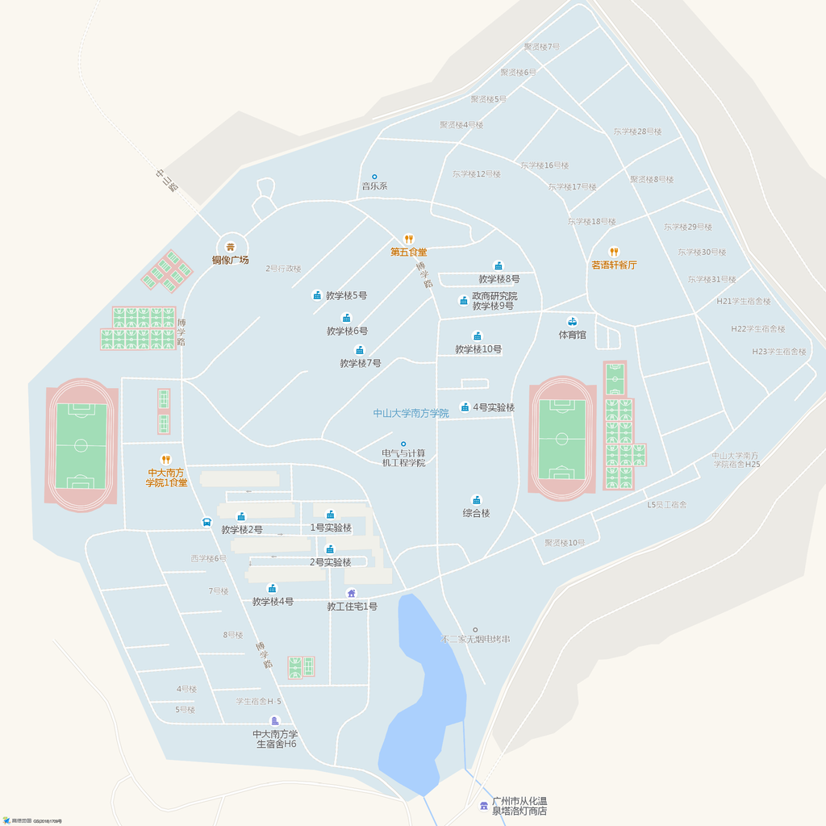

```python
map_("113.679287,23.632575")
```

- 静态地图没有涉及ML、AI的功能

```python
# 坐标转换
key_huang = '679ab0b5933e8e27c9a7ccd7a36a554c'
def convert(locations):
    """坐标转换"""
    url = "https://restapi.amap.com/v3/assistant/coordinate/convert?parameters"
    params = {
        "key" : key_huang,
        "locations":locations
    }
    response = requests.get(url,params=params)
    data = response.json()
    return data
```

```python
convert("116.481499,39.990475|116.481499,39.990375")
```

```
{'status': '1',
 'info': 'ok',
 'infocode': '10000',
 'locations': '116.481499,39.990475|116.481499,39.990375'}
```

- 坐标转换使用了机器学习功能，需要机器学习才能使返回的坐标更加精确。

```python
# 天气查询
key_huang = '679ab0b5933e8e27c9a7ccd7a36a554c'
def weather(city):
    """天气查询"""
    url = "https://restapi.amap.com/v3/weather/weatherInfo?parameters"
    params = {
        "key" : key_huang,
        "city":city
    }
    response = requests.get(url,params=params)
    data = response.json()
    return data
```

```python
weather("广东")
```

```
{'status': '1',
 'count': '1',
 'info': 'OK',
 'infocode': '10000',
 'lives': [{'province': '广东',
   'city': '广东省',
   'adcode': '440000',
   'weather': '多云',
   'temperature': '24',
   'winddirection': '东北',
   'windpower': '≤3',
   'humidity': '64',
   'reporttime': '2019-10-16 22:45:00'}]}
```

- 天气查询使用了机器学习功能，这样反馈的结果才会更加精确。

```python
# 输入提示
key_huang = '679ab0b5933e8e27c9a7ccd7a36a554c'
def inputtips(keywords):
    """输入提示"""
    url = "https://restapi.amap.com/v3/assistant/inputtips?parameters"
    params = {
        "key" : key_huang,
        "keywords":keywords
    }
    response = requests.get(url,params=params)
    data = response.json()
    return data
```

```python
inputtips("麦当劳")
```

```
{'status': '1',
 'count': '10',
 'info': 'OK',
 'infocode': '10000',
 'tips': [{'id': 'B036706ZVC',
   'name': '麦当劳(春城得来速店)',
   'district': '云南省昆明市官渡区',
   'adcode': '530111',
   'location': '102.726165,25.018468',
   'address': '春城路166-168号上海沙龙首层',
   'typecode': '050302',
   'city': []},
  {'id': 'B001C7XFZZ',
   'name': '麦当劳(郫都区店)',
   'district': '四川省成都市金牛区',
   'adcode': '510106',
   'location': '103.978189,30.724212',
   'address': '蜀西路399号',
   'typecode': '050302',
   'city': []},
  {'id': 'B001C808BT',
   'name': '麦当劳(伊藤洋华堂)',
   'district': '四川省成都市武侯区',
   'adcode': '510107',
   'location': '104.021568,30.646216',
   'address': '二环路西一段逸都路6号伊藤洋华堂双楠店1层',
   'typecode': '050302',
   'city': []},
  {'id': 'B001C806EK',
   'name': '麦当劳(欢乐谷餐厅)',
   'district': '四川省成都市金牛区',
   'adcode': '510106',
   'location': '104.035489,30.719447',
   'address': '沙西线1号华侨城公园广场',
   'typecode': '050302',
   'city': []},
  {'id': 'B001C8059O',
   'name': '麦当劳(软件园店)',
   'district': '四川省成都市武侯区',
   'adcode': '510107',
```

[output cut: 29 more lines]

```
   'name': '麦当劳(日月光中心广场店)',
   'district': '重庆市渝中区',
   'adcode': '500103',
   'location': '106.571660,29.553722',
   'address': '民权路89号日月光中心广场B1层',
   'typecode': '050302',
   'city': []},
  {'id': 'B001D0YL8Z',
   'name': '麦当劳(西安北站)',
   'district': '陕西省西安市未央区',
   'adcode': '610112',
   'location': '108.938627,34.374275',
   'address': '文景路北口西安北站F3层',
   'typecode': '050302',
   'city': []}]}
```

- 输入提示使用了机器学习功能，只有用户使用多了，机器才能学习更多不同的提示，从而更方便的给予正确的提示。

```python
# 矩形区域交通态势
key_huang = '679ab0b5933e8e27c9a7ccd7a36a554c'
def rectangle(rectangle):
    """矩形区域交通态势"""
    url = "https://restapi.amap.com/v3/traffic/status/rectangle?parameters"
    params = {
        "key" : key_huang,
        "rectangle":rectangle
    }
    response = requests.get(url,params=params)
    data = response.json()
    return data
```

```python
rectangle("116.351147,39.966309;116.357134,39.968727")
```

```
{'status': '1',
 'info': 'OK',
 'infocode': '10000',
 'trafficinfo': {'description': '北三环路：双向畅通。',
  'evaluation': {'expedite': '100.00%',
   'congested': '0.00%',
   'blocked': '0.00%',
   'unknown': '0.00%',
   'status': '1',
   'description': '整体畅通'}}}
```

- 矩形交通态势没有涉及ML、AI的功能

```python
# 地理围栏
def weilan(name):
    """创建围栏"""
    url = 'https://restapi.amap.com/v4/geofence/meta?key=679ab0b5933e8e27c9a7ccd7a36a554c'
    params = {
        'key':key_huang,
        "name": "测试围栏名称",
        "center": "115.672126,38.817129",
        "radius": "1000",
        "enable": "true",
        "valid_time": "2017-05-19",
        "repeat": "Mon,Tues,Wed,Thur,Fri,Sat,Sun",
        "time": "00:00,11:59;13:00,20:59",
        "desc": "测试围栏描述",
        "alert_condition": "enter;leave"
    }
    response = requests.get(url,params=params)
    data = response.json()
    return data
```

```python
weilan('测试围栏名称')
```

```
{'data': {'page_no': 1, 'page_size': 20, 'rs_list': [], 'total_record': 0},
 'errcode': 0,
 'errdetail': None,
 'errmsg': 'OK',
 'ext': None}
```

- 地理围栏使用了机器学习功能才能使围栏结果更加精确

```python
# 轨迹纠偏
def guiji(name):
    """轨迹纠偏"""
    url = 'https://restapi.amap.com/v4/grasproad/driving'
    params = {
        'key':key_huang,
        "x": 116.449429,
        "y": 40.014844,
        "sp": 4,
        "ag": 110,
        "tm": 1478831753
        }, {
        "x": 116.449639,
        "y": 40.014776,
        "sp": 3,
        "ag": 110,
        "tm": 23
        }, {
        "x": 116.449859,
        "y": 40.014716,
        "sp": 3,
        "ag": 111,
        "tm": 33
        }, {
        "x": 116.450074,
        "y": 40.014658,
        "sp": 3,
        "ag": 110,
        "tm": 31
        }, {
        "x": 116.450273,
        "y": 40.014598,
        "sp": 3,
        "ag": 111,
        "tm": 20
    }
    response = requests.get(url,params=params)
    data = response.json()
    return data
```

# 应用设计——"你在哪"APP

### 用户上传一张地点图片，APP接入计算机视觉功能，识别到图片的拍摄地点信息。接入高德api IP定位功能定位到图片拍摄地址，识别出具体地址后，启用路径规划api规划到此地的最佳路径，接着启用天气查询api和交通态势api，查找到此地的天气状况和通向此地的交通拥堵情况。